# Herramientas de phyloseq

```r
library(phyloseq)
```

Ejercicio de recapitulacion; como guardar en un phyloseq

```r
# paso 1: subir tabla de dada
load("taxa_ch_proy2_1_esp.RData") #identificar taxonomia
load("seq_conteos_proy2.RData") # abundancia ASVs

# paso 2: metadados
metadatos <- data.frame(Tratamiento= "Bioestimulante",
                        Suelo= "No salino")
row.names(metadatos) <- "S81"

# paso 3: renombar las muestras
row.names(seqtab.nochim_proy2) <- "S81"

# paso 4: cambiar nombres de secuencias y crar secuencia en objeto
rando <- function(n = 5000) {
  a <- do.call(paste0, replicate(5, sample(LETTERS, n, TRUE), FALSE))
  paste0(a, sprintf("%04d", sample(9999, n, TRUE)), sample(LETTERS, n, TRUE))
} # esta es una funcion y no se modifica

dim(seqtab.nochim_proy2) # para revisar cuantas filas y columnas tengo en mi tabla, en parentesis va como se llama nuestra tabla
seqnames <- rando(3961) # el resultado de la funcion anterior va en este parentesis, se encuentra en corchetes en el ambiente

# Guardar las secuencias en otro objeto antes de borrarlas
Secuencias <- colnames(seqtab.nochim_proy2)
write.csv(Secuencias, "~/RStudio/CursoInnovak/Materiales/Secuencias_ejercicio_phyloseq.csv")

# cambiar nombre con codigo
colnames(seqtab.nochim_proy2) <- seqnames

# paso 5: Cambiando nombre a las secuencias en taxa
row.names(taxa_proy2_esp_2) <- seqnames

# paso FINAL:
vid_bio <- phyloseq(otu_table(seqtab.nochim_proy2,
                              taxa_are_rows = FALSE),
                    sample_data(metadatos),
                    tax_table(taxa_proy2_esp_2))

save(vid_bio, file = "VidS81.RData")
```

Introducción

Como vimos antes de irnos phyloseq nos ayuda a integrar todos nuestros datos en un objeto para poder analizarlos. La clase vamos a ver como phyloseq nos deja modificar estos objetos para visualizarlos mejor y seguir con los diferentes tipos de analisis usando mis datos de maestria

```r
load("VidS81.RData") #siempre empezar con un objeto de phyloseq, en este caso ya no corro este codigo proque ya lo tengo en el ambiente (mi archivo se llama VidS81.RData pero en el ambiente le escribimos vid_bio)
```

# las primeras visualizaciones de nuestros datos

[figure not shown]

```r
plot_heatmap(vid_bio, taxa.label = "Phylum") # no corre porque es solo una muestra
```

Si bien con estos datos ya podemos realizar graficos que nos acercan mas al analisis el hecho es de que si siempre es conveniente pre-procesar los datos antes de cualquier grafico. Para ello phyloseq nos ofrece varias herramientas:

# Pre-procesamiento de datos

## Filtrado

### Prune vs Subset

```r
# Subset, usa los datos de la tabla de taxonomia (datos de identificacion), quito phylum porque filtra tax_table
Actino <- subset_taxa(vid_bio, #objeto
                      Phylum=="Actinobacteriota") #la condicion puede ser cualquier categoria/nivel de la jerarquia taxonomica por ejemplo genero,etc
#muestra actino = 873

# Prune, quita muestras, filtra el out_table
Actino <- prune_samples(sample_sums(Actino)>=50, #condicion
                        Actino) #objeto
```

## Union o merge

```r
# Uniendo muestras
Tratamientos <- merge_samples(vid_bio, #objeto
                              "Tratamiento") #condicion de metadatos
```

### Ejercicio

Unir las muestras de todos

[figure not shown]

## Abundancia relativa

DADA2 nos da abundancias absoluta, osea si conto 10 mil secuencias pues son 10 mil secuencias. Las cuales pasamos a nuestro objeto de phyloseq. Por lo tanto, la abundancia absoluta es un conteo TOTAL de la especies e individuos dentro de cada especie (las relativas se usan para graficos y cuando queremos comparar graficas),

La abundancia relativa nos ayuda a comparar diferentes muestras, osea normaliza nuestras muestras para poder compararlas entre si. Para ello, usa proporciones siendo 1 el 100% de nuestro conteo por muestras. De esta manera podemos comparar la composicion de nuestras muestras aunque no tengamos valores totales o absolutos iguales. (no importa que de una muestra tenga mas que otra muestra).

# Reexplorarmos graficos

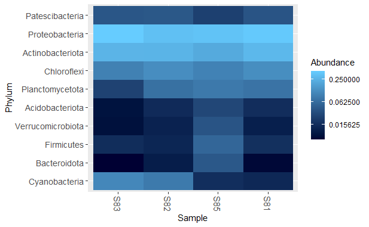

```r
plot_heatmap(Top_phyla, taxa.label = "Phylum")
```